# Case Study 2

Jonathan Flores, Melissa Luzardo, Randy Park

April 2, 2018

# Introduction

DDSAnalytics is an analytics company that specializes in talent management solutions for Fortune 1000 companies. Talent management is defined as the iterative process of developing and retaining employees. It may include workforce planning, employee training programs, identifying high-potential employees and reducing/preventing voluntary employee turnover (attrition). To gain a competitive edge over its competition, DDSAnalytics decided to leverage data science for talent management. The executive leadership identified predicting employee turnover as its first application of data science for talent management. Before the business green lights the project, they tasked the data science team to conduct an analysis of existing employee data. The scope of this report is to summarize those findings.

To conduct exploratory data analysis (EDA), the data science team was provided with CaseStudy2Data.zip file to determine factors that lead to attrition. From this data, the team was asked to identify (at least) the top three factors that contribute to turnover, to learn about any job role specific trends that may exist in the data set (e.g., “Data Scientists have the highest job satisfaction”) and to provide any other interesting trends and observations. All the Experiments and analysis were conducted in R.

#EDA

## Loading data file from GitHub

1. Saved the excel fie into GitHub. The code below reads straight from GitHubs URL.

```r
#load requeried library
library("readxl")
require(RCurl)
## After unziping the provided datafile, the .xlsl document was loaded on GitHub, the code below process information from GitHub instead of our local computers.

download.file("https://raw.githubusercontent.com/cyberkoolman/msds.6306.case.study.2/master/CaseStudy2-data.xlsx", "data2.xlsx", mode="wb")

## Assign file to object

case_data <- data.frame(read_excel("data2.xlsx"))
```

## Making the raw data tidy data

###1. Removing non-value added variables from the data set:

The following variable were removed: EmployeeCount, Over18 and StandardHours. These variables were removed because 1. EmployeeCount: Always 1, since the data set is by employee. 2. Over18: All employees are “Y”. Age is a more meaningful and relevant variable. 3. StandardHours: All are “80”.

```r
#Remove redundandt info: EmployeeCount, Over18, StandardHours

df <- case_data[,-c(9,22,27)]
```

###2. Covertiving character variables to factors and factors to numeric variables as need

To evaluate correlations we used use numeric variables, and evaluate whether the correlations were positive or negative for character variables. Later we used the factor variables for further analysis. Here used two data frames, one with level and numeric variables and one with only numeric variables.

```r
# First load required libraries.

library(purrr)
library(dplyr)
```

```r
library(knitr)
library(pander)

# Convert characters to factors.
df %>% map_if(is.character, as.factor) %>% as_data_frame -> df

#Adjust factor levels as needed
levels(df$BusinessTravel)<-c("Non-Travel","Travel_Rarely","Travel_Frequently")

#Make all variable numeric
numdf<-data.frame(sapply(df,as.numeric))
```

## Attrition in data set

Once the data set was ready for evaluation, the attrition content was determined.

```r
#Calculate attrition in data set
AT <- table(df$Attrition)
pander(AT)
```

| No | Yes |
| --- | --- |
| 1233 | 237 |

```r
#And percentages
at<-data.frame(table(df$Attrition))
pander(prop.table(at[,2]))
```

*0.8388* and *0.1612* respectively.

##Find correlation coeffientes between parameters and Attrition The correlation coefficients were calculated between numeric variables, paying closer attention to highest correating coeffients with Attrition

```r
#Correlate variables
Attcor<-data.frame(cor(numdf))

#Create Attrition object for Attrition correlation coefficients
Attrition<- data.frame(Attcor$Attrition)

#Name attrition rows
Attrition$Parameter<-row.names(Attcor)

#Rename titles Attrition
names(Attrition)<-c("Correlation", "Parameter")

#Sort positive Attrition
SortAtt <- Attrition[order(-Attrition$Correlation),]

#Display top 10 Positively Correlated Parameters
row.names(SortAtt)<-NULL
knitr::kable(head(SortAtt,10))
```

| Correlation | Parameter |
| --- | --- |
| 1.0000000 | Attrition |
| 0.2461180 | OverTime |
| 0.1620702 | MaritalStatus |
| 0.0779236 | DistanceFromHome |
| 0.0671515 | JobRole |
| 0.0639906 | Department |
| 0.0434937 | NumCompaniesWorked |
| 0.0294533 | Gender |
| 0.0268455 | EducationField |
| 0.0151702 | MonthlyRate |

## Generate graphics for visualization of coeffiecients and correlations

Graphics will all the variables and just the highest correlations were generated. Also, bar graphs displayed for the highest correlations

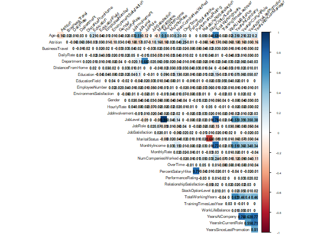

```r
# Load library to visualize correlations
library(corrplot)
#Display graphic with all correlations
par(cex=.5)
corrplot(as.matrix(Attcor), method="color",
         type="upper",
         addCoef.col = "black",
         tl.col="black", tl.srt=45,
         sig.level = 0.05, insig = "blank",
         diag=FALSE)
```

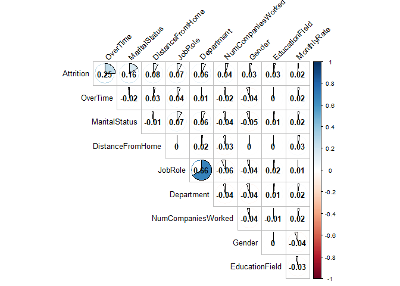

```r
#Display graphic with the top 10 positively correlated parameter
par(cex=.8)
SA10<-c(head(SortAtt$Parameter,10))
corrplot(as.matrix(Attcor[SA10,SA10]), method="pie",
         type="upper",
         addCoef.col = "black",
         tl.col="black", tl.srt=45,
         sig.level = 0.05, insig = "blank",
         diag=FALSE)
```

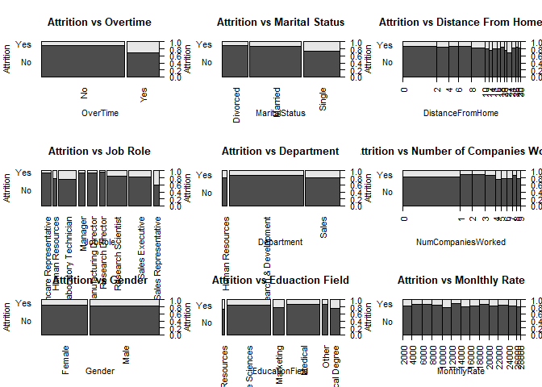

```r
# Further look at top 10 positively correlated parameters with Attrition
par(mfrow=c(3,3), las=2)
plot(Attrition~OverTime, data=df, main="Attrition vs Overtime")
plot(Attrition~MaritalStatus, data=df, main="Attrition vs Marital Status")
plot(Attrition~DistanceFromHome, data=df, main="Attrition vs Distance From Home")
plot(Attrition~JobRole, data=df, main="Attrition vs Job Role")
plot(Attrition~Department, data=df, main="Attrition vs Department")
plot(Attrition~NumCompaniesWorked, data=df, main= "Attrition vs Number of Companies Worked")
plot(Attrition~Gender, data=df, main= "Attrition vs Gender" )
plot(Attrition~EducationField, data=df, main="Attrition vs Eduaction Field")
plot(Attrition~MonthlyRate, data=df, main="Attrition vs Monlthly Rate")
```

##Check the absolute values of the highly correlated parameters with Attrition. And verify with graphics. Because the level variables were converted to numeric variables, it is possible that strong correlations are reported as negative correlations. To account for this fact, we looked at the correlation absolute values as well.

```r
##Calculate absolute value coefficients
Attrition$AbsAtt <- (Attrition$Correlation^2)^(1/2)
SortAbstAtt<- Attrition[order(-Attrition$AbsAtt),]

#Display top 10 Absolute Correlated Parameters
row.names(SortAbstAtt)<-NULL
knitr::kable(head(SortAbstAtt,10))
```

| Correlation | Parameter | AbsAtt |
| --- | --- | --- |
| 1.0000000 | Attrition | 1.0000000 |
| 0.2461180 | OverTime | 0.2461180 |
| -0.1710632 | TotalWorkingYears | 0.1710632 |
| -0.1691048 | JobLevel | 0.1691048 |
| 0.1620702 | MaritalStatus | 0.1620702 |
| -0.1605450 | YearsInCurrentRole | 0.1605450 |
| -0.1598396 | MonthlyIncome | 0.1598396 |
| -0.1592050 | Age | 0.1592050 |
| -0.1561993 | YearsWithCurrManager | 0.1561993 |
| -0.1371449 | StockOptionLevel | 0.1371449 |

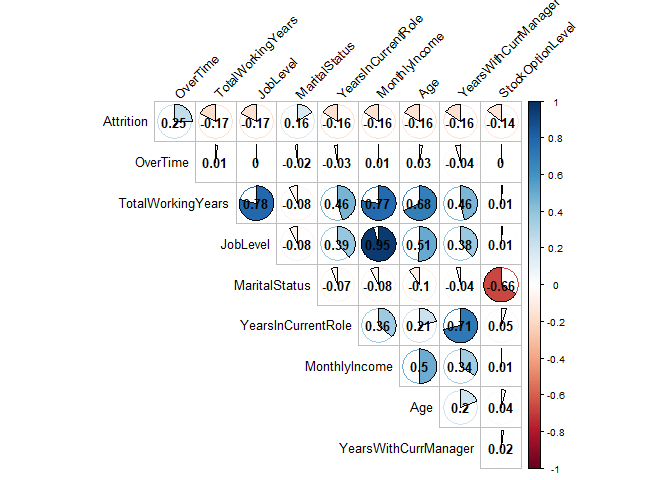

```r
#Display graphic with top 10 Absolute Correlated Parameters
par(cex=.8)
SAA10<-c(head(SortAbstAtt$Parameter,10))
corrplot(as.matrix(Attcor[SAA10,SAA10]), method="pie",
         type="upper",
         addCoef.col = "black",
         tl.col="black", tl.srt=45,
         sig.level = 0.05, insig = "blank",
         diag=FALSE)
```

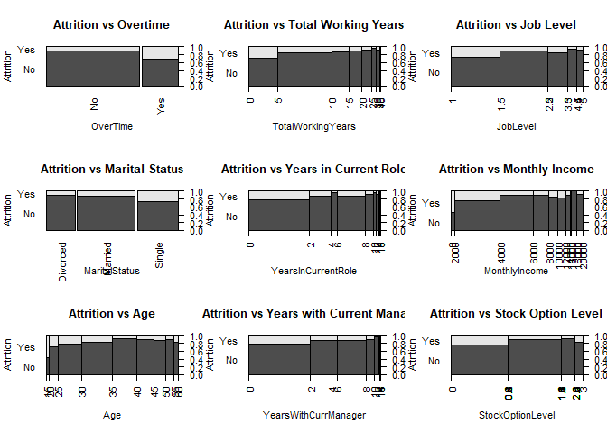

```r
#Further look at top 10 absolute correlated parameters with Attrition
par(mfrow=c(3,3), las=2)
plot(Attrition~OverTime, data=df, main="Attrition vs Overtime")
plot(Attrition~TotalWorkingYears, data=df, main="Attrition vs Total Working Years")
plot(Attrition~JobLevel, data=df, main="Attrition vs Job Level")
plot(Attrition~ MaritalStatus, data=df, main="Attrition vs Marital Status")
plot(Attrition~YearsInCurrentRole, data=df, main="Attrition vs Years in Current Role")
plot(Attrition~MonthlyIncome, data=df, main="Attrition vs Monthly Income")
plot(Attrition~Age, data=df, main="Attrition vs Age")
plot(Attrition~YearsWithCurrManager, data=df, main="Attrition vs Years with Current Manager")
plot(Attrition~StockOptionLevel, data=df, main="Attrition vs Stock Option Level")
```

# Looking at Job Role Specific Trends

To answer question regarding Job specific trends. First we looked at Job Role and its relation with attrition. And then looked at correlations between the other parameters and Job Role

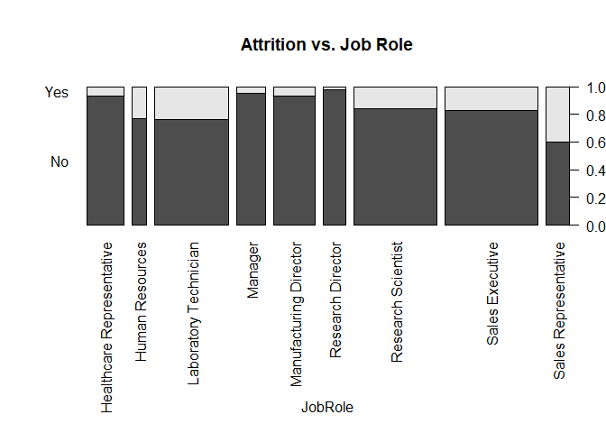

```r
# Display Job Role and Attrition correlation bar graph
par(mar=c(12, 5, 5, 2.1),mgp=c(10, 1, 0),las=2)
plot(Attrition~JobRole, data=df, main="Attrition vs. Job Role")
```

```r
#Generate object for Job Role correlation coefficients
JobRole<- data.frame(Attcor$JobRole)

#Name JobRole rows
JobRole$Parameter<-row.names(Attcor)

#Rename titles Attrition
names(JobRole)<-c("Correlation", "Parameter")

##Calculate absolute value coefficients
JobRole$Abs <- (JobRole$Correlation^2)^(1/2)
SortJobRole<- JobRole[order(-JobRole$Abs),]

#Display top 5 Absolute Correlated Parameters
row.names(SortJobRole)<-NULL
knitr::kable(head(SortJobRole))
```

| Correlation | Parameter | Abs |
| --- | --- | --- |
| 1.0000000 | JobRole | 1.0000000 |
| 0.6624312 | Department | 0.6624312 |
| -0.1454391 | TotalWorkingYears | 0.1454391 |
| -0.1224267 | Age | 0.1224267 |
| -0.0939511 | MonthlyIncome | 0.0939511 |
| -0.0854574 | JobLevel | 0.0854574 |

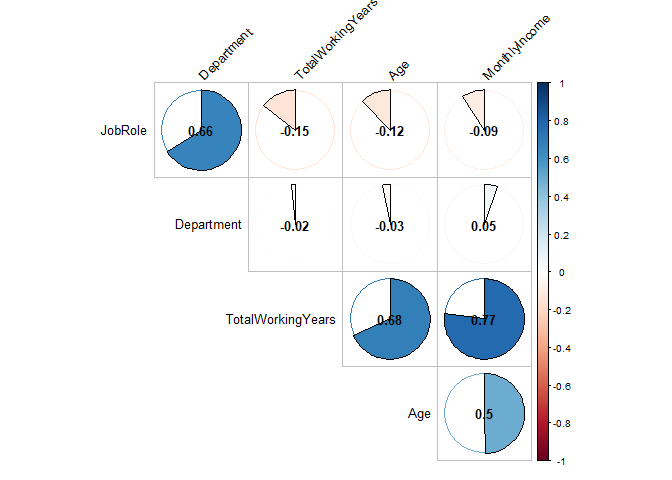

```r
#Display graphic with top 4 Absolute Correlated Parameters
par(cex=.8)
SJR5<-c(head(SortJobRole$Parameter,5))
corrplot(as.matrix(Attcor[SJR5,SJR5]), method="pie",
         type="upper",
         addCoef.col = "black",
         tl.col="black", tl.srt=45,
         sig.level = 0.05, insig = "blank",
         diag=FALSE)
```

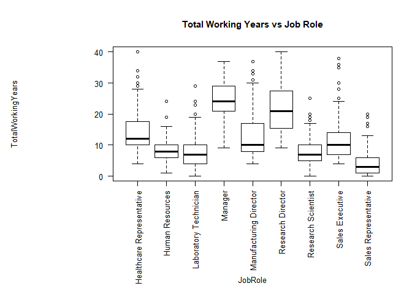

```r
#Further look at top 4 absolute correlated parameters with Job ROle
par(las=2)
par(mar=c(12, 12, 5, 2.1),mgp=c(10, 1, 0),las=2)
plot(TotalWorkingYears~JobRole, data=df, main="Total Working Years vs Job Role")
```

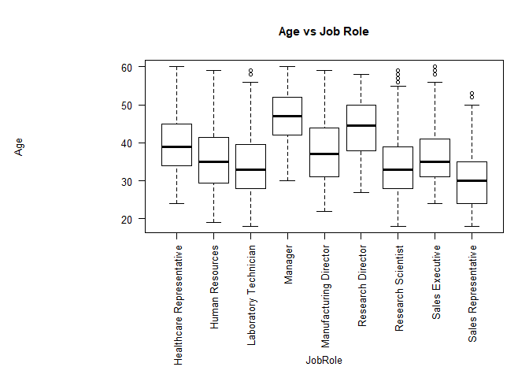

```r
plot(Age~JobRole, data=df, main="Age vs Job Role")
```

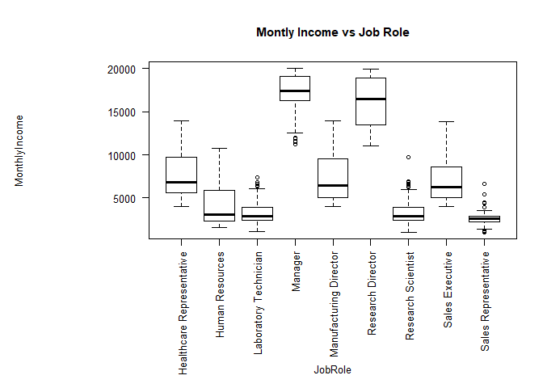

```r
plot(MonthlyIncome~JobRole, data=df, main= "Montly Income vs Job Role")
```